# **Predicting the NBA Champion using Data Science**

Collaborators: Ayman Chowdhury, Keshav Ganapathy, Julian Javillo, Sahit Kadthala

## **Introduction**

The analysis of this project was formulated with the intention of exploring the key steps involved in data science. Towards this end, we have taken it upon ourselves to investigate how an NBA team's common regular season metrics such as its average points per game, avergae rebounds per game, average field goal percentage, and so forth over the course of the year influence its probability at winning a championship.

For more context, the NBA stands for the National Basketball Association and is a basketball league that has featured the premier basketball players in the world since its inception roughly 75 years ago. Every single season takes place from around the start of November to the start of June and includes a tournament at the end called the playoffs whose winner is deemed the "champion." Each one can be split into two chunks -- one chunk prior to the playoff tournament (called the regular season) and the other being the playoff tournament itself. Roughly the top half of NBA teams in terms of win-to-loss ratio (also known as win-loss record) make it to the playoffs, with each team paired with another and the winner of the match-up moving on to the next stage. As such, we wish to see how teams' regular season metrics can be used to predict who the nba champion will end up being. Read this [article](https://usblog.betway.com/nba/how-do-the-nba-playoffs-work-nba-playoffs-explained/) if interested in more details of how the playoffs work.

The reason we focus on the NBA is multi-fold. For one, due to the nature of how basketball is played and the meticulousness of the NBA's statkeeping, there is plenty of data that exists with regard to NBA teams' regular season performance. This means that there is plenty of data that we can use to analyze and that we can utilize to showcase the essence of data science. A quick note that should be made is that other metrics exist besides a team's points per game, rebounds per game, and so forth in the form of "advanced stats," but we want to focus on more general ones since those tend to be the ones looked upon by the common fan. Another reason is the sheer relevance and importance of the NBA and its playoffs as well as what it means for millions. Right now, the NBA playoffs are taking place, so the topic is fresh in the minds of many. Just to get an idea of how much of a cultural phenomenon the NBA and its playoffs are, according to Front Office Sports, the NBA made over 10 billion dollars in revenue (see this [article](https://frontofficesports.com/nba-tops-10b-in-revenue-for-first-time-ever/) for more details) and is commonly referenced in many popular shows and music songs of the day. The NBA brings a myriad of people together, hoping for their teams to get their hands on the grand prize of a championship, which gives a sense of how meaningful the topic of who will end up winning will be.

With that being said, we shall commence with our tutorial of the data science process. The steps go as follows:

1.) Data Collection  
2.) Data Processing  
3.) Exploratory Analysis and Visualization  
4.) Machine Learning Modeling  
5.) Insight and Conclusions

## **Data Collection**

We will develop this project using the Python language in a Jupyter Notebook which you can learn more about at [Dataquest](https://www.dataquest.io/blog/jupyter-notebook-tutorial/). Below are the import statements for the Python libraries that we will need to use to develop this project along with a headers declaration to provide credentials for our HTML requests. Pandas is a library and data analysis tool that we will use throughout this project to store and manipulate our data.

#### **Imports**

```python
#python libraries used for HTML requests
import requests
from bs4 import BeautifulSoup

#standard python libraries
import pandas as pd
import time
import matplotlib.pyplot as plt
import numpy as np
import seaborn as sns

#ml libraries
from sklearn import tree

#warnings filter for converting a HTML table to Pandas df
import warnings
warnings.simplefilter(action='ignore', category=FutureWarning)

#used in HTML requests
headers = {'User-Agent': 'Mozilla/5.0 (iPad; U; CPU OS 3_2_1 like Mac OS X; en-us) AppleWebKit/531.21.10 (KHTML, like Gecko) Mobile/7B405',
           'From': 'pleaseletmein@gmail.com'
}
```

#### **Data Storing**

We first create a dataframe that will store all per game statistics for each team during each year. We abbreviate the column names to save space in the dataframe, so here are what each of the abbreviations translate to.

```python
#Set the columns of the pandas dataframe
df_per_game = pd.DataFrame(columns=["Team", "G", "MP", "FG", "FGA", "FG%", "3P", "3PA", "3P%", "2P", "2PA", "2P%", "FT",
                          "FTA", "FT%", "ORB", "DRB", "TRB", "AST", "STL", "BLK", "TOV", "PF", "PTS", "Year", "WINNING_STATUS"])

df_advanced = pd.DataFrame(columns=["Team","Year","W", "L", "OR", "DR"])
```

We then create Basketball Reference URLs for each NBA season from 1980-1981 to 2021-2022 and scrape the per-game stats from each year into our dataframe. We note that if a team name has a * at the end, we mark them as a playoff team in our dataframe by setting their Winning Status to 1. The team that won the NBA Finals each season is marked with a Winning Status of 2 to differentiate the champions' statistics from the rest of the league.

As a general reference, it is very important to refer to databases' specific API restrictions to avoid issues regarding timeouts and blackouts from certain websites. Many websites also have their own specific formatting, which may change how data is scraped from website to website. Some websites may completely ban web scraping in which case we must respect their rules and avoid scraping their data.

NOTE: This will take a few minutes to run so try run it as few times as possible

```python
#for loop to repeat process for every season between 1980 season and 2022 season
for year in range(1981, 2023):
    #Gets URL for every requested year and retreives HTML
    yearlyURL = 'https://www.basketball-reference.com/leagues/NBA_{}.html'.format(year)
    x = requests.get(yearlyURL, headers=headers)
    soup = BeautifulSoup(x.text)
    table = soup.find('table', id ='per_game-team')
    table_advanced = soup.find('table', id ='advanced-team')

    #scrape advanced stats for wins and losses
    for row in table_advanced.tbody.findAll('tr'):
        columns = row.findAll('td')
        teamName = columns[0].text.strip()
        if (columns[0].text.strip()[-1] == "*"):
            teamName = teamName[:-1]

        columns = row.findAll('td')
        new_row = pd.Series({"Team":teamName, "Year": year, "W": float(columns[2].text.strip()), "L": float(columns[3].text.strip()),
                             "OR": float(columns[9].text.strip()),"DR": float(columns[10].text.strip())})
        df_advanced = df_advanced.append(new_row, ignore_index=True)

    #scrap per game statistics for remaining statistics
    for row in table.tbody.findAll('tr'):
        columns = row.findAll('td')

        #process whether the team made the playoffs/won the finals
        winningStatus = 0
        teamName = columns[0].text.strip()
        if (columns[0].text.strip()[-1] == "*"):
            winningStatus = 1
            teamName = teamName[:-1]

        #develop new row for each team in the current season and append to Pandas df
        new_row = pd.Series({"Team": teamName, "G": float(columns[1].text.strip()), "MP": float(columns[2].text.strip()), "FG": float(columns[3].text.strip()),
                    "FGA": float(columns[4].text.strip()), "FG%": float(columns[5].text.strip()), "3P": float(columns[6].text.strip()), "3PA": float(columns[7].text.strip()),
                   "3P%": float(columns[8].text.strip()), "2P": float(columns[9].text.strip()), "2PA": float(columns[10].text.strip()), "2P%": float(columns[11].text.strip()),
                   "FT": float(columns[12].text.strip()), "FTA": float(columns[13].text.strip()), "FT%": float(columns[14].text.strip()), "ORB": float(columns[15].text.strip()),
                   "DRB": float(columns[16].text.strip()), "TRB": float(columns[17].text.strip()), "AST": float(columns[18].text.strip()), "STL": float(columns[19].text.strip()),
                   "BLK": float(columns[20].text.strip()), "TOV": float(columns[21].text.strip()), "PF": float(columns[22].text.strip()), "PTS": float(columns[23].text.strip()),
                    "Year": year, "WINNING_STATUS": winningStatus})
        df_per_game = df_per_game.append(new_row, ignore_index=True)

    df_per_game.loc[(df_per_game["Team"] == soup.findAll("p")[2].find("a").text.strip()) & (df_per_game["Year"] == year), "WINNING_STATUS"] = 2

    #sleep delay to prevent overloading the Basketball Reference servers with web scraping
    time.sleep(5)
```

We are now left with a Pandas dataframe with each team's per game statistics from the 1980-1981 season to the 2021-2022 season and another dataframe containing each team's Wins and Losses for each season. We can analyze these dataframes with Pandas functions, along with functions from other libraries, in order to explore the data and find any interesting trends.

## **Data Processing**

```python
df = pd.merge(df_per_game, df_advanced, on=['Team', 'Year'])
df.Year = df.Year.apply(pd.to_numeric)
df.W = df.W.apply(pd.to_numeric)
df.L = df.L.apply(pd.to_numeric)
df['W%'] = round(df['W']/df['G'], 2)
```

The next step is to account for the fact that some teams changed locations over the course of the 41 year dataset. To account for this, we will substitute old team names with modern team names using Pandas functions to reduce the number of individual teams that we are working with.

```python
df.loc[df['Team']=="Charlotte Bobcats", 'Team'] = "Charlotte Hornets"
df.loc[df['Team']=="Kansas City Kings", 'Team'] = "Sacramento Kings"
df.loc[df['Team']=="New Jersey Nets", 'Team'] = "Brooklyn Nets"
df.loc[df['Team']=="New Orleans Hornets", 'Team'] = "New Orleans Pelicans"
df.loc[df['Team']=="New Orleans/Oklahoma City Hornets", 'Team'] = "New Orleans Pelicans"
df.loc[df['Team']=="San Diego Clippers", 'Team'] = "Los Angeles Clippers"
df.loc[df['Team']=="Seattle SuperSonics", 'Team'] = "Oklahoma City Thunder"
df.loc[df['Team']=="Vancouver Grizzlies", 'Team'] = "Memphis Grizzlies"
df.loc[df['Team']=="Washington Bullets", 'Team'] = "Washington Wizards"
```

Now that we have cleaned all of our required data, we can store it in a local CSV file. This allows us to use the data locally from now on and not have to ever re-run the web scraping cell to retrieve the original dataset.

```python
#write pandas dataframe to a local csv file that we create
df.to_csv('NBATeamStatistics.csv', index=False)
```

Note: This cell below is the first cell you will have to run in the future to retrieve the original dataset and save it as df. The read_csv() function reads all of our web scraped data from a local CSV file, so you no longer need to web scrape for the data, saving time in the development process of this project.

```python
#read data from local csv
df = pd.read_csv('NBATeamStatistics.csv')
df
```

|  | Team | G | MP | FG | FGA | FG% | 3P | 3PA | 3P% | 2P | ... | TOV | PF | PTS | Year | WINNING_STATUS | W | L | OR | DR | W% |
| --- | --- | --- | --- | --- | --- | --- | --- | --- | --- | --- | --- | --- | --- | --- | --- | --- | --- | --- | --- | --- | --- |
| 0 | Denver Nuggets | 82.0 | 243.4 | 46.1 | 97.1 | 0.475 | 0.4 | 1.8 | 0.207 | 45.8 | ... | 17.6 | 25.7 | 121.8 | 1981 | 0 | 37.0 | 45.0 | 109.4 | 109.8 | 0.45 |
| 1 | Milwaukee Bucks | 82.0 | 240.9 | 45.4 | 91.1 | 0.498 | 0.4 | 1.6 | 0.229 | 45.0 | ... | 19.3 | 26.8 | 113.1 | 1981 | 1 | 60.0 | 22.0 | 108.7 | 101.8 | 0.73 |
| 2 | San Antonio Spurs | 82.0 | 241.5 | 43.5 | 88.7 | 0.491 | 0.2 | 1.0 | 0.176 | 43.4 | ... | 18.7 | 25.8 | 112.3 | 1981 | 1 | 52.0 | 30.0 | 108.5 | 105.7 | 0.63 |
| 3 | Philadelphia 76ers | 82.0 | 242.1 | 44.3 | 86.3 | 0.514 | 0.2 | 1.0 | 0.226 | 44.1 | ... | 20.8 | 25.1 | 111.7 | 1981 | 1 | 62.0 | 20.0 | 107.0 | 99.5 | 0.76 |
| 4 | Los Angeles Lakers | 82.0 | 241.5 | 46.1 | 90.0 | 0.512 | 0.2 | 1.1 | 0.181 | 45.9 | ... | 19.0 | 23.8 | 111.2 | 1981 | 1 | 54.0 | 28.0 | 107.6 | 103.9 | 0.66 |
| ... | ... | ... | ... | ... | ... | ... | ... | ... | ... | ... | ... | ... | ... | ... | ... | ... | ... | ... | ... | ... | ... |
| 1167 | New York Knicks | 82.0 | 241.2 | 37.7 | 86.2 | 0.437 | 13.2 | 36.9 | 0.357 | 24.5 | ... | 13.3 | 20.4 | 106.5 | 2022 | 0 | 37.0 | 45.0 | 110.4 | 110.5 | 0.45 |
| 1168 | Portland Trail Blazers | 82.0 | 240.6 | 38.5 | 87.1 | 0.442 | 12.7 | 36.8 | 0.346 | 25.8 | ... | 14.5 | 21.1 | 106.2 | 2022 | 0 | 27.0 | 55.0 | 107.8 | 116.9 | 0.33 |
| 1169 | Detroit Pistons | 82.0 | 241.2 | 38.2 | 88.6 | 0.431 | 11.3 | 34.6 | 0.326 | 26.9 | ... | 14.2 | 21.9 | 104.8 | 2022 | 0 | 23.0 | 59.0 | 106.0 | 113.8 | 0.28 |
| 1170 | Orlando Magic | 82.0 | 241.2 | 38.3 | 88.3 | 0.434 | 12.2 | 36.9 | 0.331 | 26.1 | ... | 14.5 | 19.7 | 104.2 | 2022 | 0 | 22.0 | 60.0 | 104.5 | 112.5 | 0.27 |
| 1171 | Oklahoma City Thunder | 82.0 | 241.5 | 38.3 | 89.1 | 0.430 | 12.1 | 37.4 | 0.323 | 26.2 | ... | 14.0 | 18.3 | 103.7 | 2022 | 0 | 24.0 | 58.0 | 104.6 | 112.8 | 0.29 |

1172 rows × 31 columns

#### **Tidying Data**

A key aspect of data processing is ensuring that our dataframe is tidy. A tidy dataframe should have column names that are variables, not values. When that is not the case, then our data is called "messy." For example, let's say there is a table about grades that students received on a particular exam. If there is a column for each letter grade and the table's data points are simply the frequency of each letter, then the data is messy. Look at this [resource](http://vita.had.co.nz/papers/tidy-data.pdf) if interested in more information.

Based on the table above, it is clear that each column represents a variable, each observation contains values, and there is no mish-mash of observational units, so our table is already tidy -- there is no need to do table manipulation (melting, etc) to make it so.

#### **Accounting for Missing Values**

We also have to account for missing values and the relationship they hold to the observed and unobserved values that we have collected. In order to see whether or not there are missing values in the first place, we will run: df.isna().any(). If the result is false for each and every column, then that means we do not need to estimate the missing values or do other such procedures.

```python
df.isna().any()
```

```
Team              False
G                 False
MP                False
FG                False
FGA               False
FG%               False
3P                False
3PA               False
3P%               False
2P                False
2PA               False
2P%               False
FT                False
FTA               False
FT%               False
ORB               False
DRB               False
TRB               False
AST               False
STL               False
BLK               False
TOV               False
PF                False
PTS               False
Year              False
WINNING_STATUS    False
W                 False
L                 False
OR                False
DR                False
W%                False
dtype: bool
```

As can be seen from the above output, the value is false for each column in our dataframe, which means that there are no missing values.

## **Exploratory Analysis and Visualization**

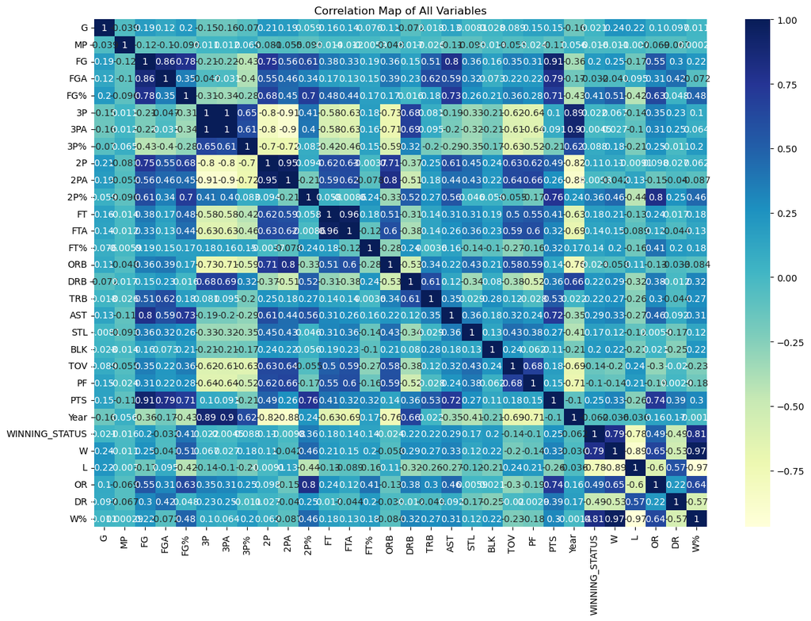

```python
# correlation map of all the variables
plt.figure(figsize=(15, 10))
sns.heatmap(df.corr(), annot=True, cmap="YlGnBu")
plt.title("Correlation Map of All Variables")
plt.show()
```

We first create a copy of our dataframe so that we can analyze its features without affecting the data that we have collected.

```python
df_cp1 = df.copy()
```

After this, we set our dataframe to be indexed by the year. We do this so that when we create our plot, the average points per game will be plotted in relation to the year.

```python
df_cp1.set_index("Year", inplace=True)
```

We then group our dataframe by the team and plot the average points per game per year of every team into a line graph.

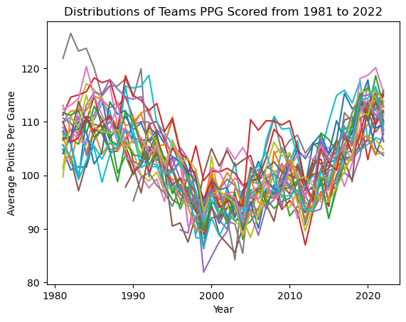

```python
df_cp1.groupby("Team")["PTS"].plot(legend=False, xlabel= "Year", ylabel ="Average Points Per Game",
                                                 title = "Distributions of Teams PPG Scored from 1981 to 2022");
```

This line graph shows that the average points scored per game decreased from 1980-2000, but has recently been on the rise from 2000-2022. However, this does not give much insight into any particular team that has been excelling, which shows that we must observe more data to reach a more concrete hypothesis.

To make the graph more readable, we group the data by the year and take the total mean of all the team's points per game and graph into a single line.

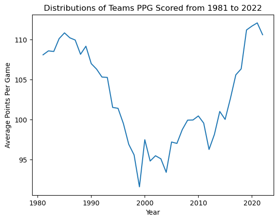

```python
df_cp1.groupby("Year")["PTS"].mean().plot(legend=False, xlabel= "Year", ylabel ="Average Points Per Game",
                                                 title = "Distributions of Teams PPG Scored from 1981 to 2022");
```

This graph clearly shows the decrease in the average points per game from 1980-2000, and the rise from 2000-2022.

A possible hypothesis for this dip is that a higher number of teams decreases the points per game because it disperses offensive talent over more teams. To observe whether this is true, we will group and count the number of teams, and plot it against the year.

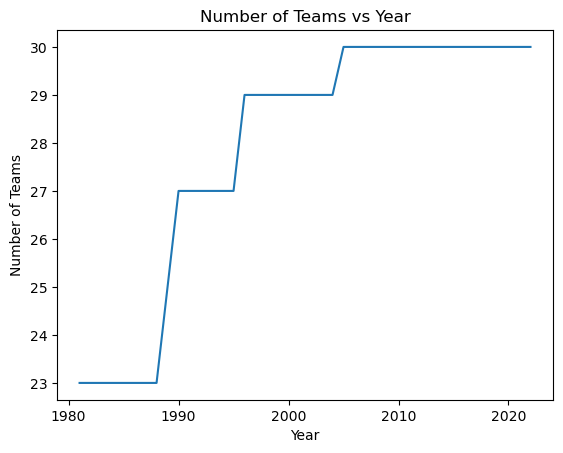

```python
df_cp1.groupby("Year")["Team"].count().plot(xlabel = "Year", ylabel = "Number of Teams",
                                           title = "Number of Teams vs Year");
```

We then create another copy of our dataframe and we find the average number of turnovers and win percentages per team. We do this by creating 2 new sub dataframes using .groupby and .mean, and then merge them back together by grouping by team name.

```python
df_cp2 = df.copy()
tov = df_cp2.groupby("Team")["TOV"].mean().reset_index()
ppg = df_cp2.groupby("Team")["W%"].mean().reset_index()

df_cp2 = pd.merge(ppg, tov, how='left', on = 'Team')
```

We then create a plot with a regression line to show the linear relationship between turnovers and win percentages. We also go through each point in the plot to label them with their respective teams.

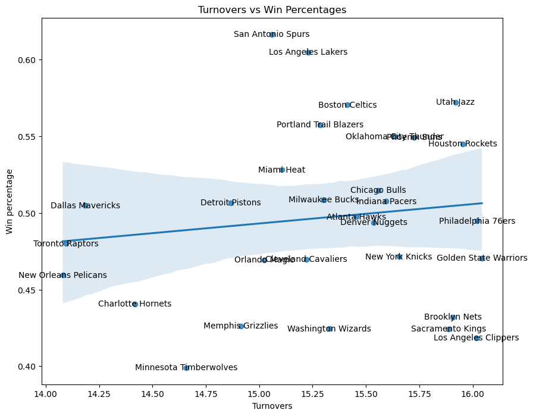

```python
plt.figure(figsize=(10,8))
sns.regplot(x='TOV', y='W%', data=df_cp2)
for x, y, label in zip(df_cp2["TOV"], df_cp2["W%"], df_cp2["Team"]):
    plt.text(x, y, label, ha='center', va='center')

plt.title("Turnovers vs Win Percentages")
plt.xlabel("Turnovers")
plt.ylabel("Win percentage")
plt.show()
```

This plot shows that there is a slight linear relationship between turnovers and win percentage between teams, but there is not any substantial evidence that turnovers directly lead to a higher chance of winning.

We then create another copy of our dataframe to observe the relationship between the win percentage and average number of points per game. We use a similar method as before to group these statistics by team name, and merge the two dataframes by team name.

```python
df_cp3 = df_cp1.copy()

winper = df_cp3.groupby("Team")["W%"].mean().reset_index()
ppg = df_cp3.groupby("Team")["PTS"].mean().reset_index()

df_cp3 = pd.merge(ppg, winper, how='left', on = 'Team')
```

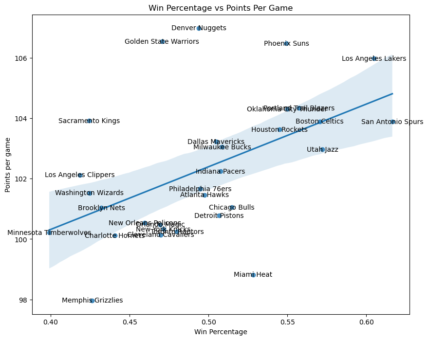

```python
plt.figure(figsize=(10,8))
sns.regplot(x='W%', y='PTS', data=df_cp3)
for x, y, label in zip(df_cp3["W%"], df_cp3["PTS"], df_cp3["Team"]):
    plt.text(x, y, label, ha='center', va='center')

plt.title("Win Percentage vs Points Per Game")
plt.xlabel("Win Percentage")
plt.ylabel("Points per game")
plt.show()
```

## **Machine Learning Modeling**

#### **Decision Tree**

```python
# Load libraries
import pandas as pd
from sklearn.tree import DecisionTreeClassifier
from sklearn.model_selection import train_test_split
from sklearn import metrics
```

```python
df_dec = df.copy()

#feature_cols = ["FG", "3P", "2P", "FT%", "AST", "STL", "W", "L"]

feature_cols = ["FG", "FGA", "3P", "3P%", "2P", "FT",
      "FTA", "FT%", "AST", "STL", "BLK", "PF", "PTS", "Year",
    "W", "L"]

#feature_cols = ["FG", "FGA", "FG%", "3P", "3P%", "2P", "2P%", "FT",
#      "FTA", "FT%", "AST", "STL", "BLK", "TOV", "PF", "PTS", "Year",
#    "W", "L", "OR", "DR"]

#feature_cols = ["G", "MP", "FG", "FGA", "FG%", "3P", "3PA", "3P%", "2P", "2PA", "2P%", "FT",
#      "FTA", "FT%", "ORB", "DRB", "TRB", "AST", "STL", "BLK", "TOV", "PF", "PTS", "Year",
#     "W", "L", "OR", "DR", "W%"]

X = df_dec[feature_cols]
y = df.WINNING_STATUS

X_train, X_test, y_train, y_test = train_test_split(X, y, test_size=0.3, random_state=1) # 70% training and 30% test

# Create Decision Tree classifer object
clf = DecisionTreeClassifier()

# Train Decision Tree Classifer
clf = clf.fit(X_train,y_train)

#Predict the response for test dataset
y_pred = clf.predict(X_test)

# Model Accuracy, how often is the classifier correct?
print("Accuracy:",metrics.accuracy_score(y_test, y_pred))
```

```
Accuracy: 0.8380681818181818
```

```python
df_dec = df.copy()

feature_cols = ["FG", "3P", "2P", "FT%", "AST", "STL", "W", "L"]

#feature_cols = ["FG", "FGA", "FG%", "3P", "3P%", "2P", "2P%", "FT",
#      "FTA", "FT%", "AST", "STL", "BLK", "TOV", "PF", "PTS", "Year",
#    "W", "L", "OR", "DR"]

#feature_cols = ["G", "MP", "FG", "FGA", "FG%", "3P", "3PA", "3P%", "2P", "2PA", "2P%", "FT",
#      "FTA", "FT%", "ORB", "DRB", "TRB", "AST", "STL", "BLK", "TOV", "PF", "PTS", "Year",
#     "W", "L", "OR", "DR", "W%"]

X = df_dec[feature_cols]
y = df.WINNING_STATUS

X_train, X_test, y_train, y_test = train_test_split(X, y, test_size=0.3, random_state=1) # 70% training and 30% test

from sklearn import linear_model
# logistic regression, max iter allows logistic regression to converge
log_reg = linear_model.LogisticRegression(max_iter=5000)
log_reg.fit(X_train, y_train)
lscore = log_reg.score(X_test, y_test)
print("Logistic Regression Accuracy: ", lscore)
```

```
Logistic Regression Accuracy:  0.9034090909090909
```

```python
df_dec = df.copy()

#feature_cols = ["FG", "3P", "2P", "FT%", "AST", "STL", "W", "L"]

feature_cols = ["FG", "FG%", "3P", "3P%", "2P", "2P%", "FT",
      "FTA", "FT%", "STL", "BLK", "PF", "PTS",
    "W", "L"]

#feature_cols = ["G", "MP", "FG", "FGA", "FG%", "3P", "3PA", "3P%", "2P", "2PA", "2P%", "FT",
#      "FTA", "FT%", "ORB", "DRB", "TRB", "AST", "STL", "BLK", "TOV", "PF", "PTS", "Year",
#     "W", "L", "OR", "DR", "W%"]

X = df_dec[feature_cols]
y = df.WINNING_STATUS

X_train, X_test, y_train, y_test = train_test_split(X, y, test_size=0.3, random_state=1) # 70% training and 30% test

from sklearn.svm import SVC
# SVM
svm = SVC(gamma='auto')
svm.fit(X_train, y_train)
sscore = svm.score(X_test, y_test)
print("SVM Accuracy: ", sscore)
```

```
SVM Accuracy:  0.8693181818181818
```

```python
df_dec = df.copy()

#feature_cols = ["FG", "3P", "2P", "FT%", "AST", "STL", "W", "L"]

feature_cols = ["FG", "FGA", "FG%", "3P", "3P%", "2P", "2P%", "FT",
      "FTA", "FT%", "AST", "STL", "BLK", "TOV", "PF", "PTS", "Year",
     "W", "L", "OR", "DR"]

#feature_cols = ["FG", "FGA", "FG%", "3P", "3P%", "2P", "2P%", "FT",
#      "FTA", "FT%", "AST", "STL", "BLK", "TOV", "PF", "PTS", "Year",
#    "W", "L", "OR", "DR"]

#feature_cols = ["G", "MP", "FG", "FGA", "FG%", "3P", "3PA", "3P%", "2P", "2PA", "2P%", "FT",
#      "FTA", "FT%", "ORB", "DRB", "TRB", "AST", "STL", "BLK", "TOV", "PF", "PTS", "Year",
#     "W", "L", "OR", "DR", "W%"]

X = df_dec[feature_cols]
y = df.WINNING_STATUS

X_train, X_test, y_train, y_test = train_test_split(X, y, test_size=0.3, random_state=1) # 70% training and 30% test

from sklearn.neighbors import KNeighborsClassifier
# KNN
kfin = 0
kscore = 0
for k in range(1,21):
    knn = KNeighborsClassifier(n_neighbors=k)
    knn.fit(X_train, y_train)
    score = knn.score(X_test, y_test)
    if score > kscore:
        kfin = k
        kscore = score
    print("K Nearest Neighbors Accuracy for k = ", k, ": ", score)
```

```
K Nearest Neighbors Accuracy for k =  1 :  0.8125
K Nearest Neighbors Accuracy for k =  2 :  0.8295454545454546
K Nearest Neighbors Accuracy for k =  3 :  0.8323863636363636
K Nearest Neighbors Accuracy for k =  4 :  0.8494318181818182
K Nearest Neighbors Accuracy for k =  5 :  0.8636363636363636
K Nearest Neighbors Accuracy for k =  6 :  0.8607954545454546
K Nearest Neighbors Accuracy for k =  7 :  0.875
K Nearest Neighbors Accuracy for k =  8 :  0.8664772727272727
K Nearest Neighbors Accuracy for k =  9 :  0.8693181818181818
K Nearest Neighbors Accuracy for k =  10 :  0.8607954545454546
K Nearest Neighbors Accuracy for k =  11 :  0.8607954545454546
K Nearest Neighbors Accuracy for k =  12 :  0.8721590909090909
K Nearest Neighbors Accuracy for k =  13 :  0.8693181818181818
K Nearest Neighbors Accuracy for k =  14 :  0.8721590909090909
K Nearest Neighbors Accuracy for k =  15 :  0.8636363636363636
K Nearest Neighbors Accuracy for k =  16 :  0.8693181818181818
K Nearest Neighbors Accuracy for k =  17 :  0.8636363636363636
K Nearest Neighbors Accuracy for k =  18 :  0.875
K Nearest Neighbors Accuracy for k =  19 :  0.8721590909090909
K Nearest Neighbors Accuracy for k =  20 :  0.8721590909090909
```